# Project: Investigation on No-show appointments

- Introduction
- Data Wrangling
- Exploratory Data Analysis
- Conclusions

## Introduction

```python
#Import packages
import numpy as np
import pandas as pd
import matplotlib.pyplot as plt
```

The dataset chosen is No-showappointments in a hospital in Brazil

## Questions

1.What age groups visit the hospital?

2.Top neighbourhoods with maximum and no-shows and shows?

3.Do same day appointments help in reducing no-shows?

4.How does scholarship/welfare program affect no-shows?

## Data Wrangling

Gather data - Load csv file and print the top 5 rows

Analyze the dimensional and statistical information of the dataset

```python
# Load your data and print out a few lines. Perform operations to inspect data
data = pd.read_csv('C:/Users/avala/Downloads/noshowappointments-kagglev2-may-2016.csv')
print(data.head())
```

```
      PatientId  AppointmentID Gender          ScheduledDay  \
0  2.987250e+13        5642903      F  2016-04-29T18:38:08Z
1  5.589978e+14        5642503      M  2016-04-29T16:08:27Z
2  4.262962e+12        5642549      F  2016-04-29T16:19:04Z
3  8.679512e+11        5642828      F  2016-04-29T17:29:31Z
4  8.841186e+12        5642494      F  2016-04-29T16:07:23Z

         AppointmentDay  Age      Neighbourhood  Scholarship  Hipertension  \
0  2016-04-29T00:00:00Z   62    JARDIM DA PENHA            0             1
1  2016-04-29T00:00:00Z   56    JARDIM DA PENHA            0             0
2  2016-04-29T00:00:00Z   62      MATA DA PRAIA            0             0
3  2016-04-29T00:00:00Z    8  PONTAL DE CAMBURI            0             0
4  2016-04-29T00:00:00Z   56    JARDIM DA PENHA            0             1

   Diabetes  Alcoholism  Handcap  SMS_received No-show
0         0           0        0             0      No
1         0           0        0             0      No
2         0           0        0             0      No
3         0           0        0             0      No
4         1           0        0             0      No
```

```python
#Shape of data
print("shape:",data.shape)
```

```
shape: (110527, 14)
```

```python
#Data types
print("Data types \n",data.dtypes)
```

```
Data types
 PatientId         float64
AppointmentID       int64
Gender             object
ScheduledDay       object
AppointmentDay     object
Age                 int64
Neighbourhood      object
Scholarship         int64
Hipertension        int64
Diabetes            int64
Alcoholism          int64
Handcap             int64
SMS_received        int64
No-show            object
dtype: object
```

```python
#Summary statistics and general info
print(data.info())
print("Data Description \n",data.describe())
```

```
<class 'pandas.core.frame.DataFrame'>
RangeIndex: 110527 entries, 0 to 110526
Data columns (total 14 columns):
PatientId         110527 non-null float64
AppointmentID     110527 non-null int64
Gender            110527 non-null object
ScheduledDay      110527 non-null object
AppointmentDay    110527 non-null object
Age               110527 non-null int64
Neighbourhood     110527 non-null object
Scholarship       110527 non-null int64
Hipertension      110527 non-null int64
Diabetes          110527 non-null int64
Alcoholism        110527 non-null int64
Handcap           110527 non-null int64
SMS_received      110527 non-null int64
No-show           110527 non-null object
dtypes: float64(1), int64(8), object(5)
memory usage: 11.8+ MB
None
Data Description
           PatientId  AppointmentID            Age    Scholarship  \
count  1.105270e+05   1.105270e+05  110527.000000  110527.000000
mean   1.474963e+14   5.675305e+06      37.088874       0.098266
std    2.560949e+14   7.129575e+04      23.110205       0.297675
min    3.921784e+04   5.030230e+06      -1.000000       0.000000
25%    4.172614e+12   5.640286e+06      18.000000       0.000000
50%    3.173184e+13   5.680573e+06      37.000000       0.000000
75%    9.439172e+13   5.725524e+06      55.000000       0.000000
max    9.999816e+14   5.790484e+06     115.000000       1.000000

        Hipertension       Diabetes     Alcoholism        Handcap  \
count  110527.000000  110527.000000  110527.000000  110527.000000
mean        0.197246       0.071865       0.030400       0.022248
std         0.397921       0.258265       0.171686       0.161543
min         0.000000       0.000000       0.000000       0.000000
25%         0.000000       0.000000       0.000000       0.000000
50%         0.000000       0.000000       0.000000       0.000000
75%         0.000000       0.000000       0.000000       0.000000
max         1.000000       1.000000       1.000000       4.000000

        SMS_received
count  110527.000000
mean        0.321026
std         0.466873
min         0.000000
25%         0.000000
50%         0.000000
75%         1.000000
max         1.000000
```

```python
#Unique values in each column
print("Unique Data Values \n",data.nunique())
#Listing out the columns
for i, v in enumerate(data.columns):
    print(i, v)
```

```
Unique Data Values
 PatientId          62299
AppointmentID     110527
Gender                 2
ScheduledDay      103549
AppointmentDay        27
Age                  104
Neighbourhood         81
Scholarship            2
Hipertension           2
Diabetes               2
Alcoholism             2
Handcap                5
SMS_received           2
No-show                2
dtype: int64
0 PatientId
1 AppointmentID
2 Gender
3 ScheduledDay
4 AppointmentDay
5 Age
6 Neighbourhood
7 Scholarship
8 Hipertension
9 Diabetes
10 Alcoholism
11 Handcap
12 SMS_received
13 No-show
```

### Data Cleaning

- Missing Values
- Duplicates
- Incorrect Data Formats

## Missing Values

```python
#print(data[data['Age']==-1])
print("Missing values",data.isnull().sum())
```

```
Missing values PatientId         0
AppointmentID     0
Gender            0
ScheduledDay      0
AppointmentDay    0
Age               0
Neighbourhood     0
Scholarship       0
Hipertension      0
Diabetes          0
Alcoholism        0
Handcap           0
SMS_received      0
No-show           0
dtype: int64
```

> The output tells us that we dont have any missing values in the dataset

## Duplicate Values

```python
print("Duplicate values",sum(data.duplicated()))
```

```
Duplicate values 0
```

> We dont have any duplicates in the dataset

## Incorrect Data Formats

> Since ScheduleDay and AppointmentDay are in String we'll have to convert that to date type and exclude the timestamps since I'll be using only dates in my analysis

```python
data['ScheduledDay']=pd.to_datetime(data['ScheduledDay'])
data['ScheduledDate'] = data['ScheduledDay'].dt.date
data['AppointmentDay']=pd.to_datetime(data['AppointmentDay'])
data['AppointmentDate'] = data['AppointmentDay'].dt.date
```

## Exploratory Data Analysis

### Research Question 1 - What age groups visit the hospital?

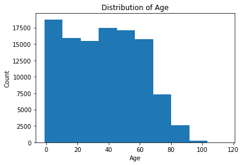

```python
plt.hist(data['Age'])

plt.title('Distribution of Age')
plt.xlabel('Age')
plt.ylabel('Count')

plt.show()
```

> The age group ranges from -1 to 115. Although age -1 doesn't make any sense, we can still retain the row because it's a no show and that's our primary class of interest.

> This plot is to just give us an understanding of age range. We will not be performing any further analysis on Age

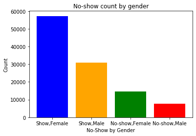

```python
bars = ('Show,Female', 'Show,Male', 'No-show,Female', 'No-show,Male')
y_pos = np.arange(len(bars))
plt.bar(y_pos,data['Gender'].groupby(data['No-show']).value_counts(),color=('Blue','orange','green','red'))

# Add title and axis names
plt.title('No-show count by gender')
plt.xlabel('No-Show by Gender')
plt.ylabel('Count')

plt.xticks(y_pos, bars)

plt.show()
```

> We see that female gender is dominant in both turning up and notshowing up for their appointments.

### Research Question 2 - Top neighbourhoods with maximum no-shows and shows of patients who received SMS?

```
No-show  Neighbourhood
Yes      MARIA ORTIZ          641
         JARDIM CAMBURI       636
         RESISTÊNCIA          449
         ITARARÉ              422
         CENTRO               296
         JARDIM DA PENHA      294
         JESUS DE NAZARETH    290
         SANTO ANDRÉ          251
         ILHA DO PRÍNCIPE     250
         TABUAZEIRO           249
Name: Neighbourhood, dtype: int64
```

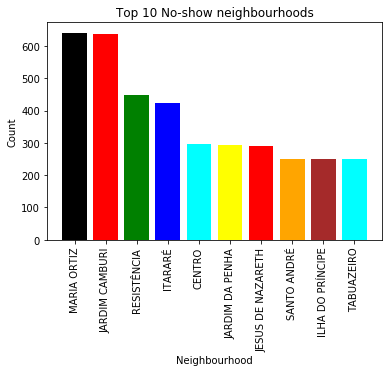

```python
#Dataset that gives us information of patients who received SMS regarding their appointments. We will further split this into show and no-show accordingly
sms_received = data[data["SMS_received"]==1]
show = sms_received[sms_received["No-show"]=="No"]
no_show = sms_received[sms_received["No-show"]=="Yes"]
print(no_show['Neighbourhood'].groupby(no_show['No-show']).value_counts().nlargest(10))

bars = ('MARIA ORTIZ', 'JARDIM CAMBURI', 'RESISTÊNCIA', 'ITARARÉ','CENTRO','JARDIM DA PENHA','JESUS DE NAZARETH','SANTO ANDRÉ','ILHA DO PRÍNCIPE','TABUAZEIRO')
y_pos = np.arange(len(bars))
plt.bar(y_pos,no_show['Neighbourhood'].value_counts().nlargest(10),color=['black', 'red', 'green', 'blue', 'cyan','yellow', 'red', 'orange', 'brown', 'aqua'])

# Add title and axis names
plt.title('Top 10 No-show neighbourhoods')
plt.xlabel('Neighbourhood')
plt.ylabel('Count')

plt.xticks(y_pos, bars, rotation=90)

plt.show()
```

> The neighbourhood with maximum no shows who received SMS is Maria Ortiz followed by Jardim Camburi with 641 and 636 no-show patients respectively

> I'd like to further drill down on Maria Ortiz neighbourhood

```
          PatientId  AppointmentID          Age  Scholarship  Hipertension  \
count  5.805000e+03   5.805000e+03  5805.000000  5805.000000   5805.000000
mean   1.468694e+14   5.661851e+06    35.275797     0.020500      0.021361
std    2.543808e+14   7.032524e+04    23.388397     0.141714      0.144597
min    4.374176e+04   5.311307e+06     0.000000     0.000000      0.000000
25%    4.615162e+12   5.614292e+06    15.000000     0.000000      0.000000
50%    2.947126e+13   5.664262e+06    35.000000     0.000000      0.000000
75%    9.512835e+13   5.714625e+06    54.000000     0.000000      0.000000
max    9.993486e+14   5.790447e+06   102.000000     1.000000      1.000000

          Diabetes   Alcoholism      Handcap  SMS_received
count  5805.000000  5805.000000  5805.000000   5805.000000
mean      0.009302     0.001378     0.001034      0.361929
std       0.096007     0.037101     0.032136      0.480600
min       0.000000     0.000000     0.000000      0.000000
25%       0.000000     0.000000     0.000000      0.000000
50%       0.000000     0.000000     0.000000      0.000000
75%       0.000000     0.000000     0.000000      1.000000
max       1.000000     1.000000     1.000000      1.000000
SMS_received  No-show
0             No         3126
              Yes         578
1             No         1460
              Yes         641
Name: No-show, dtype: int64
```

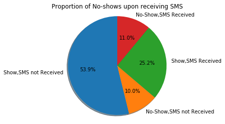

```python
maria_ortiz = data[data['Neighbourhood']==('MARIA ORTIZ')]
print(maria_ortiz.describe())
print(maria_ortiz['No-show'].groupby(maria_ortiz['SMS_received']).value_counts())

labels = 'Show,SMS not Received', 'No-Show,SMS not Received', 'Show,SMS Received', 'No-Show,SMS Received'

fig1, ax1 = plt.subplots()
ax1.pie(maria_ortiz['No-show'].groupby(maria_ortiz['SMS_received']).value_counts(), labels=labels, autopct='%1.1f%%',
        shadow=True, startangle=90)
ax1.axis('equal')  # Equal aspect ratio ensures that pie is drawn as a circle.

plt.title('Proportion of No-shows upon receiving SMS')

plt.show()
```

> This tells us that in Maria Ortiz neighbourhood people upon receiving SMS but didnt show up(641) are larger in number than people who actually didnt receive any SMS and hence didnt show up

> It's interesting that people who didnt receive an SMS actually turned up well than those who received

```
Gender  No-show
F       No         2941
        Yes         794
M       No         1645
        Yes         425
Name: No-show, dtype: int64
```

[figure not shown]

```python
#print(maria_ortiz['No-show'].groupby(maria_ortiz['Gender']).value_counts().plot(kind='pie'));
print(maria_ortiz['No-show'].groupby(maria_ortiz['Gender']).value_counts())

labels = 'Show,Female', 'No-Show,Male', 'Show,Male', 'No-Show,Female'

fig1, ax1 = plt.subplots()
ax1.pie(maria_ortiz['No-show'].groupby(maria_ortiz['SMS_received']).value_counts(), labels=labels, autopct='%1.1f%%',
        shadow=True, startangle=90)
ax1.axis('equal')  # Equal aspect ratio ensures that pie is drawn as a circle.

plt.title('Proportion of No-shows by Gender')

plt.show()
```

> This tells us that in Maria Ortiz neighbourhood, female patients who didn't show up are 794 while men are at 425

```
No-show  Neighbourhood
No       JARDIM CAMBURI     1939
         MARIA ORTIZ        1460
         JARDIM DA PENHA    1130
         RESISTÊNCIA        1054
         CENTRO              784
         ITARARÉ             729
         TABUAZEIRO          710
         JABOUR              700
         SANTO ANTÔNIO       619
         SANTO ANDRÉ         592
Name: Neighbourhood, dtype: int64
```

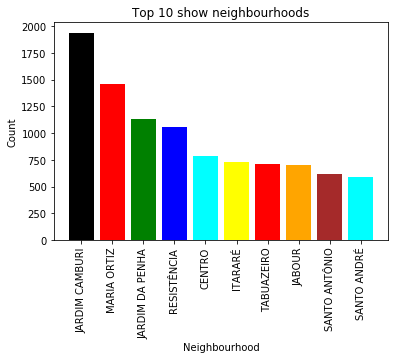

```python
print(show['Neighbourhood'].groupby(show['No-show']).value_counts().nlargest(10))
bars = ( 'JARDIM CAMBURI', 'MARIA ORTIZ', 'JARDIM DA PENHA','RESISTÊNCIA', 'CENTRO', 'ITARARÉ','TABUAZEIRO','JABOUR','SANTO ANTÔNIO','SANTO ANDRÉ')
y_pos = np.arange(len(bars))
plt.bar(y_pos,show['Neighbourhood'].groupby(show['No-show']).value_counts().nlargest(10),color=['black', 'red', 'green', 'blue', 'cyan','yellow', 'red', 'orange', 'brown', 'aqua'])

# Add title and axis names
plt.title('Top 10 show neighbourhoods')
plt.xlabel('Neighbourhood')
plt.ylabel('Count')

plt.xticks(y_pos, bars, rotation=90)

plt.show()
```

> This is to display the top 10 neighbourhoods that actually showed up

### Research Question 3 - Do same day appointments help in reducing no-shows?

```python
#same day appointments
from datetime import date
data['difference'] = data['AppointmentDate'] - data['ScheduledDate']
same_day_appointment= data[data['difference']=='0 days']

same_day_show = same_day_appointment[same_day_appointment["No-show"]=="No"]
print(same_day_show.head())
same_day_no_show = same_day_appointment[same_day_appointment["No-show"]=="Yes"]
print(same_day_no_show.head())
print(same_day_no_show['Neighbourhood'].groupby(same_day_no_show['No-show']).value_counts().nlargest(10))
print(same_day_show['Neighbourhood'].groupby(same_day_show['No-show']).value_counts().nlargest(10))
```

```
      PatientId  AppointmentID Gender        ScheduledDay AppointmentDay  Age  \
0  2.987250e+13        5642903      F 2016-04-29 18:38:08     2016-04-29   62
1  5.589978e+14        5642503      M 2016-04-29 16:08:27     2016-04-29   56
2  4.262962e+12        5642549      F 2016-04-29 16:19:04     2016-04-29   62
3  8.679512e+11        5642828      F 2016-04-29 17:29:31     2016-04-29    8
4  8.841186e+12        5642494      F 2016-04-29 16:07:23     2016-04-29   56

       Neighbourhood  Scholarship  Hipertension  Diabetes  Alcoholism  \
0    JARDIM DA PENHA            0             1         0           0
1    JARDIM DA PENHA            0             0         0           0
2      MATA DA PRAIA            0             0         0           0
3  PONTAL DE CAMBURI            0             0         0           0
4    JARDIM DA PENHA            0             1         1           0

   Handcap  SMS_received No-show ScheduledDate AppointmentDate difference
0        0             0      No    2016-04-29      2016-04-29     0 days
1        0             0      No    2016-04-29      2016-04-29     0 days
2        0             0      No    2016-04-29      2016-04-29     0 days
3        0             0      No    2016-04-29      2016-04-29     0 days
4        0             0      No    2016-04-29      2016-04-29     0 days
        PatientId  AppointmentID Gender        ScheduledDay AppointmentDay  \
145  2.373717e+13        5639602      M 2016-04-29 09:17:23     2016-04-29
212  4.266984e+14        5642059      M 2016-04-29 14:59:38     2016-04-29
250  2.942723e+14        5640181      M 2016-04-29 10:13:35     2016-04-29
251  6.537451e+11        5640178      F 2016-04-29 10:13:22     2016-04-29
440  8.366249e+13        5639495      F 2016-04-29 09:09:55     2016-04-29

     Age  Neighbourhood  Scholarship  Hipertension  Diabetes  Alcoholism  \
145   17        ITARARÉ            0             0         0           0
212   62  SANTOS DUMONT            0             1         1           0
250    0      CARATOÍRA            0             0         0           0
251   33      CARATOÍRA            1             0         0           0
440   25   SÃO BENEDITO            1             0         0           0

     Handcap  SMS_received No-show ScheduledDate AppointmentDate difference
145        0             0     Yes    2016-04-29      2016-04-29     0 days
212        0             0     Yes    2016-04-29      2016-04-29     0 days
250        0             0     Yes    2016-04-29      2016-04-29     0 days
251        0             0     Yes    2016-04-29      2016-04-29     0 days
440        0             0     Yes    2016-04-29      2016-04-29     0 days
```

[output cut: 9 more lines]

```
         ITARARÉ            54
         CARATOÍRA          50
Name: Neighbourhood, dtype: int64
No-show  Neighbourhood
No       JARDIM CAMBURI       2398
         MARIA ORTIZ          1994
         RESISTÊNCIA          1564
         SANTA MARTHA         1450
         JARDIM DA PENHA      1188
         TABUAZEIRO           1161
         ITARARÉ              1079
         JESUS DE NAZARETH    1060
         SANTO ANTÔNIO        1054
         BONFIM               1028
Name: Neighbourhood, dtype: int64
```

> People with same day appointments tend to actually show up for their slot

> In a way, same day appointments help in reducing no shows.

### Research Question 4 - How does scholarship/welfare program affect no-shows?

```
Neighbourhood      No-show
JARDIM CAMBURI     Yes        1422
MARIA ORTIZ        Yes        1184
ITARARÉ            Yes         834
RESISTÊNCIA        Yes         812
CENTRO             Yes         671
JESUS DE NAZARETH  Yes         634
JARDIM DA PENHA    Yes         630
CARATOÍRA          Yes         487
TABUAZEIRO         Yes         469
BONFIM             Yes         460
Name: No-show, dtype: int64
```

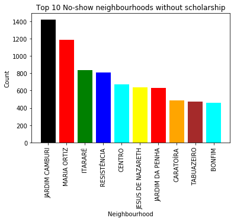

```python
no_scholarship = data[data['Scholarship']==0]
no_scholarship_no_show = no_scholarship[no_scholarship['No-show']=='Yes']
#print(no_scholarship_no_show['No-show'].groupby(no_scholarship_no_show['Neighbourhood']).value_counts().nlargest(10).plot(kind="bar"))
print(no_scholarship_no_show['No-show'].groupby(no_scholarship_no_show['Neighbourhood']).value_counts().nlargest(10))

bars = ('JARDIM CAMBURI', 'MARIA ORTIZ', 'ITARARÉ','RESISTÊNCIA', 'CENTRO', 'JESUS DE NAZARETH', 'JARDIM DA PENHA', 'CARATOÍRA', 'TABUAZEIRO','BONFIM')
y_pos = np.arange(len(bars))
plt.bar(y_pos,no_scholarship_no_show['No-show'].groupby(no_scholarship_no_show['Neighbourhood']).value_counts().nlargest(10),color=['black', 'red', 'green', 'blue', 'cyan','yellow', 'red', 'orange', 'brown', 'aqua'])

# Add title and axis names
plt.title('Top 10 No-show neighbourhoods without scholarship')
plt.xlabel('Neighbourhood')
plt.ylabel('Count')

plt.xticks(y_pos, bars, rotation=90)

plt.show()
```

> This gives us the top neighbourhoods with no scholarships and who didnt turn up for their appointments

> It'd help if people in these areas are being provided with health welfare for better treatment chances

## Conclusions

> The neighbourhood with maximum no shows upon receiving SMS is Maria Ortiz followed by Jardim Camburi with 641 and 636 no-show patients respectively

> Female gender is dominant in both turning up and not showing up for their appointments.

> In Maria Ortiz neighbourhood people who received SMS but didnt show up(641) are larger in number than people who actually didnt receive any SMS and hence didnt show up

> Maria Ortiz neighbourhood, female patients who didn't show up are 794 while men are at 425

> The age group ranges from -1 to 115. Although age -1 doesn't make any sense, we can still retain the row because it's a no show and that's our primary class of interest.

### Limitations

> Although we made some interesting observations, the features here limit us to find the actual reason behind no show appointments.

> Additional information like climatic conditions, distance between the patient residence and hospital, previous appointments and customer service might help in deriving interesting insights